# **Geospatial Data Sciences and Economic Spatial Models** *Assignment 02*

**Histogram of Average Distance to Ports/Airports by Country:** Calculates the average distance (in kilometers) from each country’s centroid to the ports/airports within its boundaries, displayed by continent.

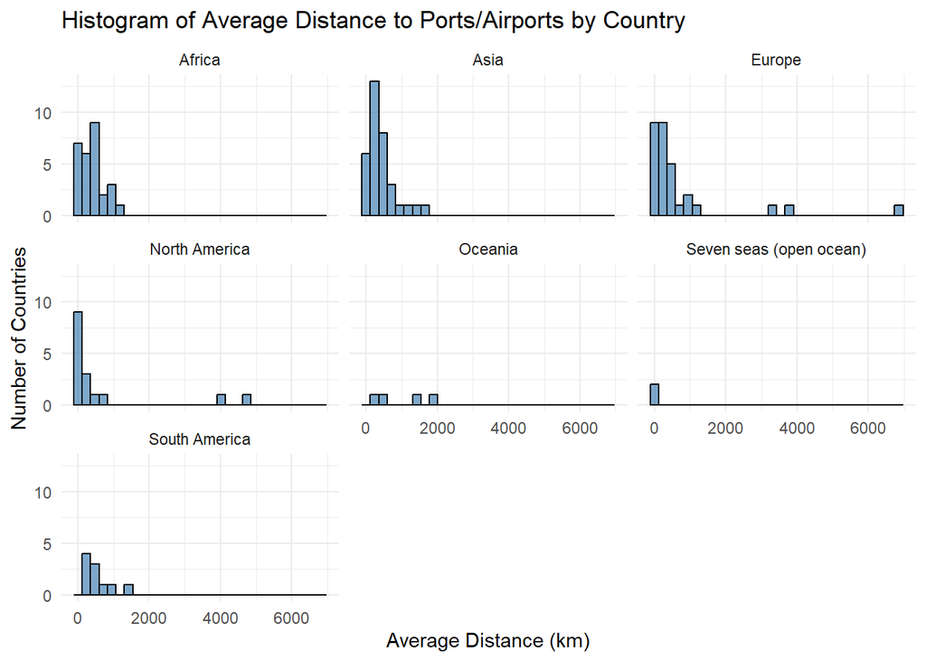

```r
# Calculate, for each country, the average distance (in km) from its centroid to the ports/airports within its boundaries.

avg_distance_list <- lapply(seq_len(nrow(world_proj)), function(i) {
  # Safely extract attributes; if absent, assign NA_character_
  country_iso       <- if (length(world_proj$iso_a3[i]) == 0) NA_character_ else as.character(world_proj$iso_a3[i])
  country_name      <- if (length(world_proj$NAME[i]) == 0) NA_character_ else as.character(world_proj$NAME[i])
  country_continent <- if (length(world_proj$CONTINENT[i]) == 0) NA_character_ else as.character(world_proj$CONTINENT[i])

  # Extract the country's polygon
  country_poly <- world_proj[i, ]

  # Check if the country's geometry is empty
  if (st_is_empty(country_poly)) {
    return(data.frame(
      iso_a3 = country_iso,
      country = country_name,
      continent = country_continent,
      avg_distance = NA_real_,
      stringsAsFactors = FALSE
    ))
  }

  # Select points that fall within the country's polygon
  in_country_logical <- st_within(pa_points_proj, country_poly, sparse = FALSE)[, 1]
  pa_in_country <- pa_points_proj[in_country_logical, ]

  if (nrow(pa_in_country) > 0) {
    # Calculate the country's centroid
    centroid <- st_centroid(country_poly)
    # If the centroid is empty, assign NA
    if (st_is_empty(centroid)) {
      avg_dist <- NA_real_
    } else {
      distances <- st_distance(centroid, pa_in_country)
      avg_dist  <- mean(as.numeric(distances)) / 1000  # Convert to kilometers
    }
  } else {
    avg_dist <- NA_real_  # No points found within the country
  }

  data.frame(
    iso_a3 = country_iso,
    country = country_name,
    continent = country_continent,
    avg_distance = avg_dist,
    stringsAsFactors = FALSE
  )
})

# Combine the list into a single data frame
avg_distance_df <- do.call(rbind, avg_distance_list)

# Filter countries that have a calculated distance (exclude those with no points)
avg_distance_df_clean <- avg_distance_df %>% filter(!is.na(avg_distance))

# Create a histogram, faceted by continent
hist_distance <- ggplot(avg_distance_df_clean, aes(x = avg_distance)) +
  geom_histogram(fill = "steelblue", bins = 30, color = "black", alpha = 0.7) +
  facet_wrap(~ continent) +
  labs(
    title = "Histogram of Average Distance to Ports/Airports by Country",
    x = "Average Distance (km)",
    y = "Number of Countries"
  ) +
  theme_minimal()

# Display the histogram
print(hist_distance)
```

## 2.2 **II. High trade costs in Africa**

The paper finds extremely high trade costs in sub-Saharan Africa, raising food prices. Targeted trade corridor investments could significantly boost welfare.

```r
sink(tempfile())

# Load data
markets <- read_excel(file.path(path_data, "1.-Price--Production--and-Population-Data/MktCoords.xlsx"))
markets <- st_as_sf(markets, coords = c("longitude", "latitude"), crs = 4326)  # Convert df to sf object

sf <- st_read(file.path(path_data, "1.-Price--Production--and-Population-Data/Catchments/MktCatch6Plus5_Dissolve.shp"))
sf.africa_cities <- rmapshaper::ms_simplify(sf, keep=0.01, keep_shapes=TRUE)
sf.africa_cities <- st_make_valid(sf.africa_cities)
sf.africa_cities <- st_cast(sf.africa_cities, "POLYGON")
st_crs(sf.africa_cities)

sink()
```

2.1 Sf POINT feature of market prices places across Africa.

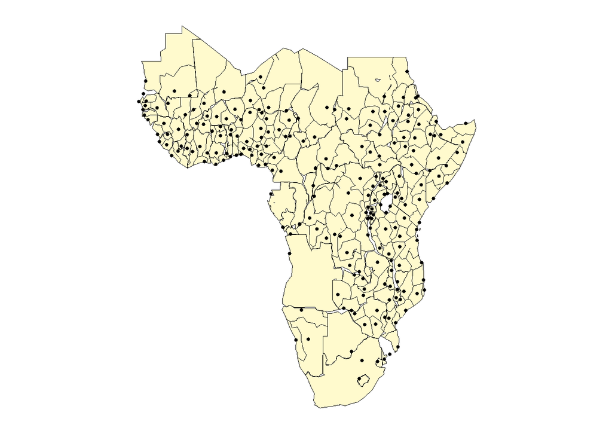

```r
ggplot() +
  geom_sf(data = sf.africa_cities, color = "black", fill = "#FFFACD") +
  geom_sf(data = markets, color = "black", fill = "black", size = 1, shape = 21) +
  theme_minimal() +
  theme(
    axis.text = element_blank(),
    axis.title = element_blank(),
    axis.ticks = element_blank(),
    panel.grid = element_blank(),
    panel.border = element_blank()
  )
```

2.2 Minimum distance

```r
sink(tempfile())

# Africa coast
africa <- ne_countries(continent = "Africa", returnclass = "sf")
coastline <- ne_download(scale = "large", type = "coastline", category = "physical", returnclass = "sf")
africa_bbox <- st_bbox(africa)  # Africa's longitude and latitude

coastline_africa <- coastline %>%
  st_crop(y = africa_bbox)
st_is_valid(coastline_africa)

coastline_africa <- st_transform(coastline_africa, crs = st_crs(markets))
st_crs(coastline_africa)
coastline_africa <- st_cast(coastline_africa, "POINT")

# https://www.earthdata.nasa.gov/data/catalog/sedac-ciesin-sedac-groads-v1-1.00
layers <- st_layers(file.path(path_data, "/groads-v1-africa-gdb/gROADS-v1-africa.gdb"))
roads <- st_read(file.path(path_data, "/groads-v1-africa-gdb/gROADS-v1-africa.gdb"), layer = "Africa_Roads")
roads <- st_simplify(roads, dTolerance = 2000)
st_is_valid(roads)
st_crs(roads)

# https://www.naturalearthdata.com/downloads/10m-cultural-vectors/airports/
airports <- st_read(file.path(path_data, "/ne_10m_airports/ne_10m_airports.shp"))
airports <- airports %>%
  mutate(longitude = st_coordinates(.)[,1],
         latitude = st_coordinates(.)[,2])
airports_africa <- airports %>%
  st_crop(y = africa_bbox)
st_is_valid(airports_africa)
st_crs(airports_africa)

sink()
```

2.2.1 Minimum Distance between Markets and Coast

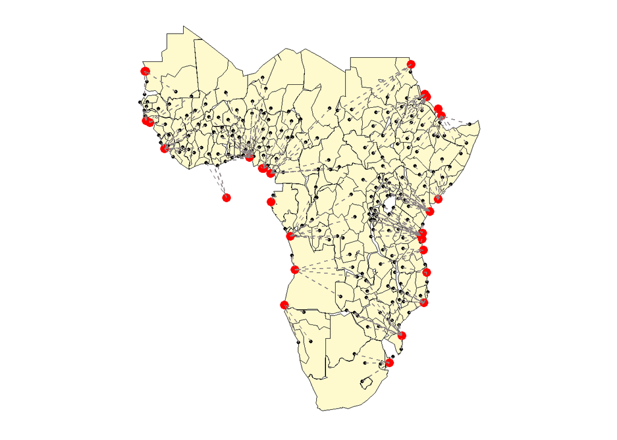

```r
sink(tempfile())

coast_distance <- st_distance(markets, coastline_africa, by_element = FALSE)
coast_min_distances <- apply(X = coast_distance, MARGIN = 1, FUN = min, na.rm = TRUE)
markets$coast_min_distances_km <- coast_min_distances / 1000

closest_coast_indices <- apply(coast_distance, 1, which.min)
closest_coast_points <- coastline_africa[closest_coast_indices, ]
markets$closest_coast <- st_geometry(closest_coast_points)

markets_coords <- st_coordinates(markets$geometry)
coast_coords <- st_coordinates(markets$closest_coast)

lines_list <- lapply(seq_len(nrow(markets)), function(i) {
  st_linestring(rbind(markets_coords[i, ], coast_coords[i, ]))
})

lines_sf <- st_sf(geometry = st_sfc(lines_list, crs = st_crs(markets)))

sink()

ggplot() +
  geom_sf(data = sf.africa_cities, color = "black", fill = "#FFFACD") +
  geom_sf(data = markets %>% st_set_geometry("geometry"), color = "black", fill = "black", size = 1, shape = 21) +
  geom_sf(data = closest_coast_points, color = "red", size = 3) +
  geom_sf(data = lines_sf, color = "#8B8386", linetype = "dashed") +
  theme_minimal() +
  theme(
    axis.text = element_blank(),
    axis.title = element_blank(),
    axis.ticks = element_blank(),
    panel.grid = element_blank(),
    panel.border = element_blank()
  )
```

2.2.2 Minimum Distance between Markets and Roads

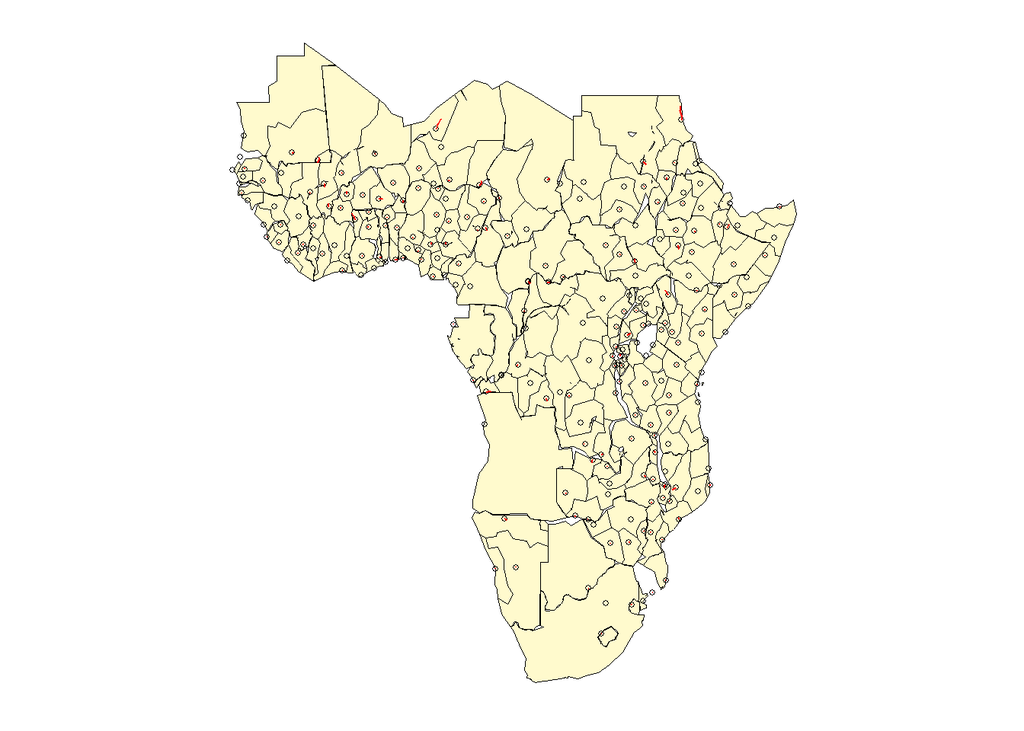

```r
sink(tempfile())

nearest_idx <- st_nearest_feature(markets, roads)
road_min_distances <- st_distance(markets, roads[nearest_idx, ], by_element = TRUE)
markets$road_min_distances_km <- road_min_distances / 1000

closest_road_points <- roads[nearest_idx, ]
markets$closest_road <- st_geometry(closest_road_points)

sink()

ggplot() +
  geom_sf(data = sf.africa_cities, color = "black", fill = "#FFFACD") +
  geom_sf(data = markets %>% st_set_geometry("geometry"), color = "black", size = 1, shape = 21) +
  geom_sf(data = markets %>% st_set_geometry("closest_road"), color = "red", fill = "red", size = 100, shape = 21) +
  theme_minimal() +
  theme(
    axis.text = element_blank(),
    axis.title = element_blank(),
    axis.ticks = element_blank(),
    panel.grid = element_blank(),
    panel.border = element_blank()
  )
```

2.2.3 Minimum Distance betweenMarkets and Airports

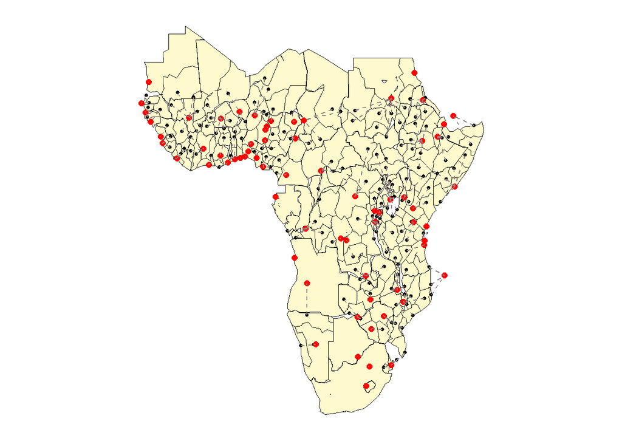

```r
sink(tempfile())

airport_distance <- st_distance(markets, airports_africa, by_element = FALSE)
airport_min_distances <- apply(X = airport_distance, MARGIN = 1, FUN = min, na.rm = TRUE)
markets$airport_min_distances_km <- airport_min_distances / 1000

closest_airport_indices <- apply(airport_distance, 1, which.min)
closest_airport_points <- airports_africa[closest_airport_indices, ]
markets$closest_airport <- st_geometry(closest_airport_points)

airport_coords <- st_coordinates(markets$closest_airport)

lines_list <- lapply(seq_len(nrow(markets)), function(i) {
  st_linestring(rbind(markets_coords[i, ], airport_coords[i, ]))
})

lines_sf <- st_sf(geometry = st_sfc(lines_list, crs = st_crs(markets)))

sink()

ggplot() +
  geom_sf(data = sf.africa_cities, color = "black", fill = "#FFFACD") +
  geom_sf(data = markets %>% st_set_geometry("geometry"), color = "black", fill = "black", size = 1, shape = 21) +
  geom_sf(data = closest_airport_points, color = "red", size = 2) +
  geom_sf(data = lines_sf, color = "#8B8386", linetype = "dashed") +
  theme_minimal() +
  theme(
    axis.text = element_blank(),
    axis.title = element_blank(),
    axis.ticks = element_blank(),
    panel.grid = element_blank(),
    panel.border = element_blank()
  )
```

According with point number 2, in the previous part we calculated the distance between each market with coast, roads and airports. Now, we produce 3 plots that relate average prices with the minimum distances:

2.3 Scatter Plots

```r
head(markets[, c("market","coast_min_distances_km", "road_min_distances_km", "airport_min_distances_km")])
```

```
## Simple feature collection with 6 features and 4 fields
## Geometry type: POINT
## Dimension:     XY
## Bounding box:  xmin: 1.388616 ymin: -24.65411 xmax: 25.90874 ymax: 11.86195
## Geodetic CRS:  WGS 84
## # A tibble: 6 × 5
##   market     coast_min_distances_km road_min_distances_km airport_min_distance…¹
##   <chr>                       <dbl>                   [m]                  <dbl>
## 1 Luanda                       256.                 2.29                    1.11
## 2 Cotonou                      245.                 0.521                   5.55
## 3 Malanville                   643.                 0.944                 223.
## 4 Natitingou                   580.                 1.67                  362.
## 5 Parakou                      414.                 0.240                 230.
## 6 Gaborone                     720.                 0.323                  10.8
## # ℹ abbreviated name: ¹airport_min_distances_km
## # ℹ 1 more variable: geometry <POINT [°]>
```

```r
# Scatter plot for average coast

market_prices <- readxl::read_excel(file.path(path_data,  "1.-Price--Production--and-Population-Data/PriceMaster4GAMS.xlsx"))

# Average price by market id

# Convert price columns to numeric
price_cols <- as.character(1:144)  # Columns "1" to "144"
market_prices[price_cols] <- lapply(market_prices[price_cols], as.numeric)

# Compute average price per mktcode, excluding 0 and NA values
avg_prices <- market_prices %>%
  rowwise() %>%
  mutate(avg_price = mean(c_across(all_of(price_cols))[c_across(all_of(price_cols)) > 0], na.rm = TRUE)) %>%
  ungroup() %>%
  group_by(mktcode) %>%
  summarise(avg_price = mean(avg_price, na.rm = TRUE))
```

2.3.1 Scatter Plot Coast distance

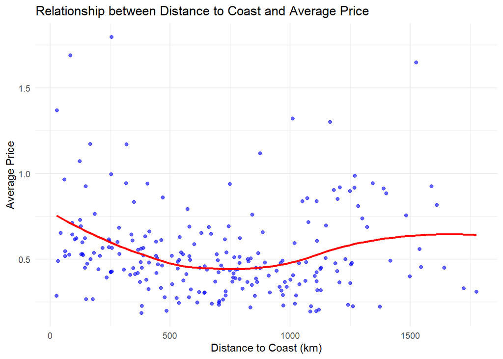

```r
# Merge avg_prices with markets using mktcode
merged_data <- markets %>%
  inner_join(avg_prices, by = "mktcode")

# Scatter plot with trend line
ggplot(merged_data, aes(x = coast_min_distances_km, y = avg_price)) +
  geom_point(color = "blue", alpha = 0.6) +
  geom_smooth(method = "loess", color = "red", se = FALSE, size=1) +  # Adds a linear trend line
  labs(title = "Relationship between Distance to Coast and Average Price",
       x = "Distance to Coast (km)",
       y = "Average Price") +
  theme_minimal()
```

2.3.2 Scatter Plot Road distance

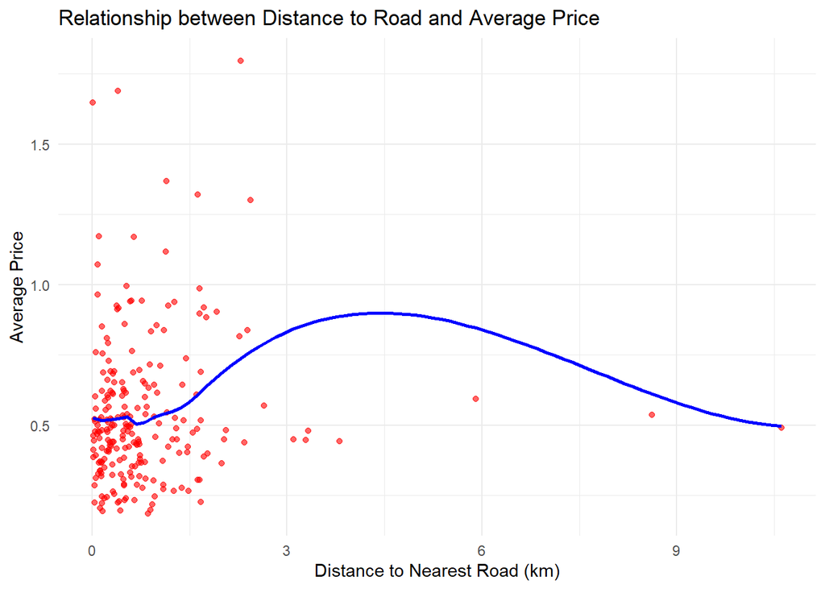

```r
# Merge avg_prices with markets using mktcode
merged_data <- markets %>%
  inner_join(avg_prices, by = "mktcode") %>%
  mutate(road_min_distances_km = as.numeric(road_min_distances_km))  # Convert units to numeric

# Scatter plot with trend line
ggplot(merged_data, aes(x = road_min_distances_km, y = avg_price)) +
  geom_point(color = "red", alpha = 0.6) +
  geom_smooth(method = "loess", color = "blue", se = FALSE, size=1) +  # Adds a linear trend line
  labs(title = "Relationship between Distance to Road and Average Price",
       x = "Distance to Nearest Road (km)",
       y = "Average Price") +
  theme_minimal()
```

2.3.3 Scatter Plot Airport distance

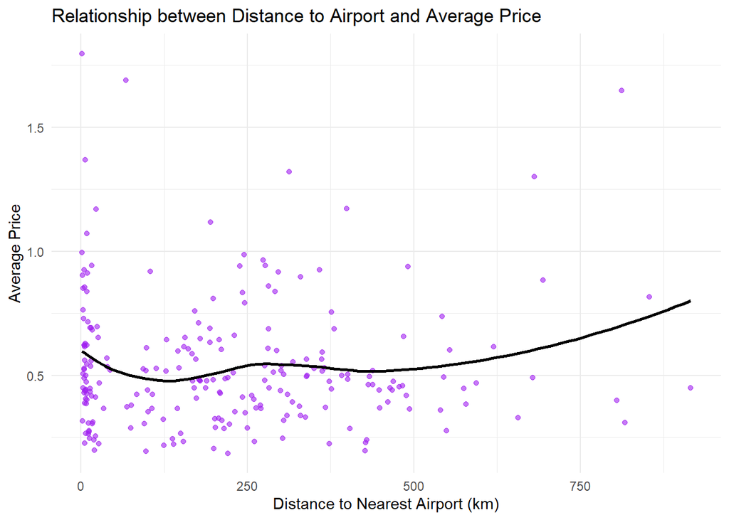

```r
# Merge avg_prices with markets using mktcode
merged_data <- markets %>%
  inner_join(avg_prices, by = "mktcode")

# Scatter plot with trend line
ggplot(merged_data, aes(x = airport_min_distances_km, y = avg_price)) +
  geom_point(color = "purple", alpha = 0.6) +
  geom_smooth(method = "loess", color = "black", size = 1, se = FALSE) +  # Adds a linear trend line
  labs(title = "Relationship between Distance to Airport and Average Price",
       x = "Distance to Nearest Airport (km)",
       y = "Average Price") +
  theme_minimal()
```